# 第４回データ分析勉強会

2018年07月29日

## 本日の内容

1. 効率的で綺麗な可視化（６０～９０分程度）
2. **演習１～５（残り）**
   - アンスコムのデータ例
     - 第３回の演習結果を可視化してみる
   - 層別散布図
     - データの見方を変えてみる
   - ヒストグラム
     - 任意の階級幅で描いてみる
   - 層別箱ひげ図
     - 変数ごとに層別してみる
   - オープン・クローズチャート
     - チケットの処理状況を把握する

## 演習問題について

演習問題に記載していない事項に関しては適宜補完してください。なお、補完した場合は補完内容を解答に記載してください。

## 演習１

## アンスコムのデータ例

アンスコムのデータ例（`anscombe`）を下図のようにグラフ化してください。

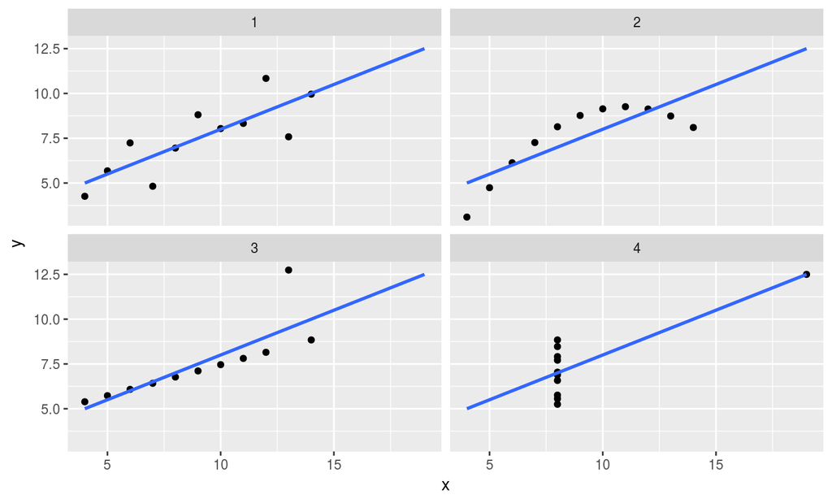

## ヒント

| やりたいこと | 利用する関数例 | 備考 |
| --- | --- | --- |
| 整然データにする | 第２回資料 |  |
| 散布図を描く | `ggplot2::geom_point()` |  |
| 回帰線を描く | `ggplot2::geom_smooth()` |  |
| 層別に描く | `ggplot2::facet_wrap()` |  |

## 演習２

## 層別散布図

`iris`データセットを下図のようにグラフ化してください。

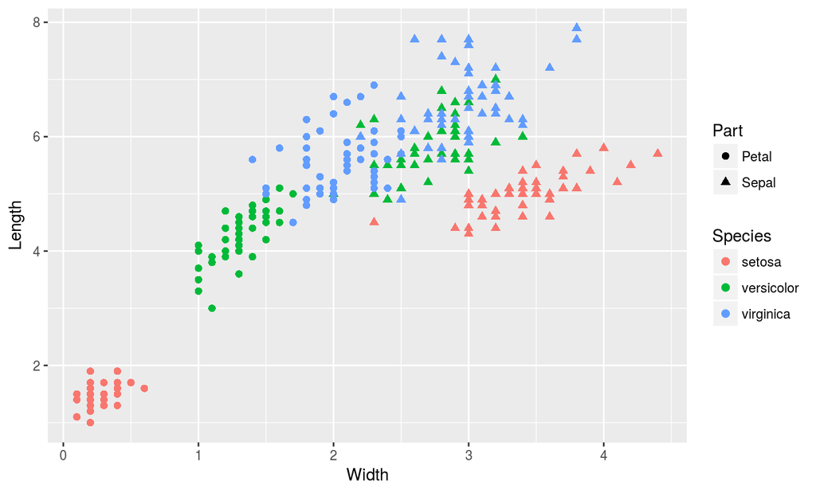

## ヒント

- 基本的な考え方は演習１に同じです

| やりたいこと | 利用する関数例 | 備考 |
| --- | --- | --- |
| 点の形を指定する | `ggplot2::aes(shape)` |  |

## 演習３

## ヒストグラム

第３回の『メトリクス統計分析入門』の演習問題にある生産性（階級幅200）と工数予実割合（階級幅0.25）のヒストグラムを描いてください。

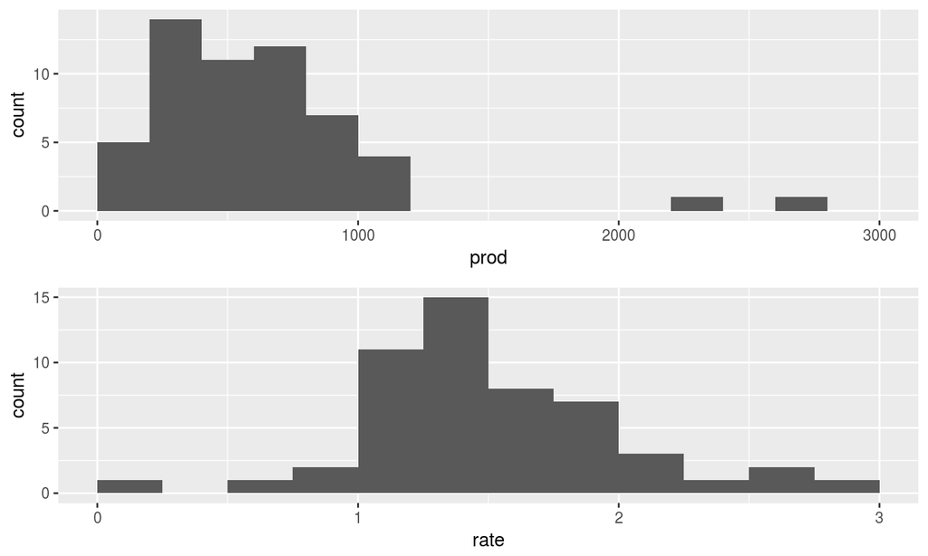

## ヒント

| やりたいこと | 利用する関数例 | 備考 |
| --- | --- | --- |
| 任意の階級を指定する | `ggplot2::geom_histgram(breaks)` |  |
| 任意の数列を作成する | `seq(start, end, by)` |  |

## 演習４

## 層別箱ひげ図

`iris`データセットを下図のようにグラフ化してください。

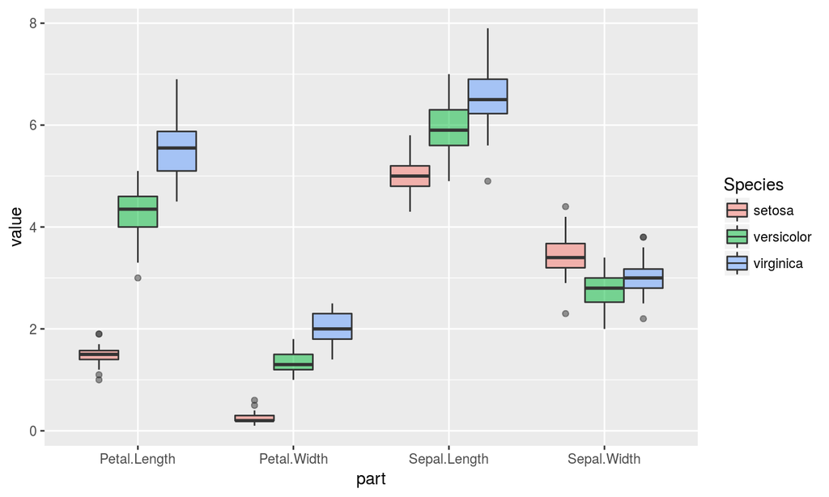

## 演習５

## オープン・クローズチャート

第３回の演習５で求めたデータを元にオープン・クローズチャートを描いてください。

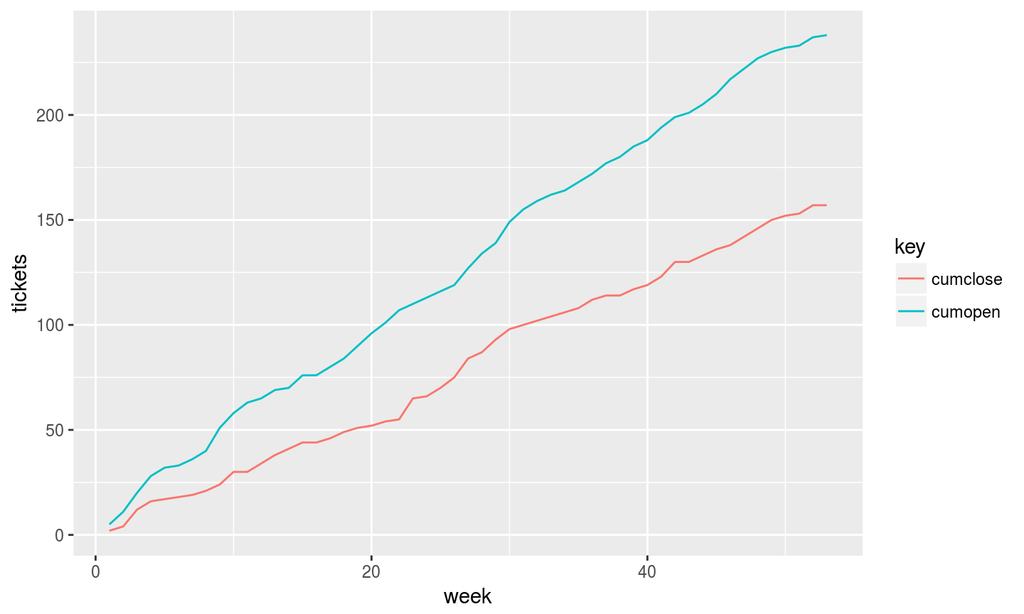

## ヒント

| やりたいこと | 利用する関数例 | 備考 |
| --- | --- | --- |
| 折れ線グラフを描く | `ggplot2::geom_line` |  |

## ここから先は任意

## 演習６

## 層別箱ひげ図

`iris`データセットのがく片（Sepal）の長さを下図のようにグラフ化してください。`All`は品種で分けない全てのデータです。

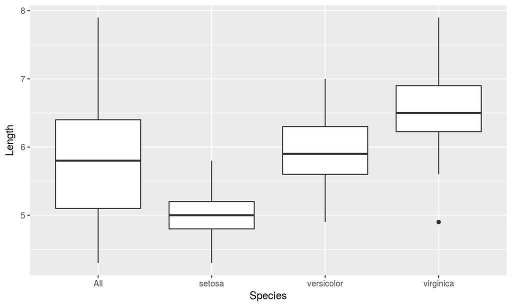

## ヒント

- 演習２の応用で因子分けされていない全体のデータをどうつくるかがポイントです

| やりたいこと | 利用する関数例 | 備考 |
| --- | --- | --- |
| データフレームをつなげる | `dplyr::row_bind()` | 行方向 |
| 層別指定する | `ggplot2::aes(group)` |  |
| 箱ひげ図を描く | `ggplot2::geom_boxplot()` |  |

## 演習７

## オープン・クローズチャート

第３回の演習５で求めたデータを元に週毎のオープン、クローズ数を棒グラフで描いてください。

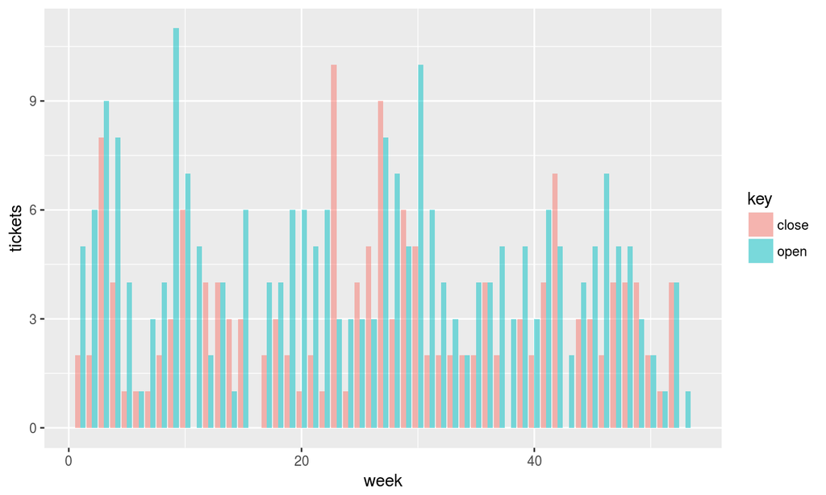

## ヒント

| やりたいこと | 利用する関数例 | 備考 |
| --- | --- | --- |
| 棒グラフを描く | `ggplot2::geom_bar` |  |
| Y軸を指定して描く | `ggplot2::geom_bar(stat)` |  |
| 因子毎に独立させて描く | `ggplot2::geom_bar(position)` |  |

## 演習８

## オープン・クローズチャート

演習５と演習７で描いたグラフを一つにまとめて描いてください。

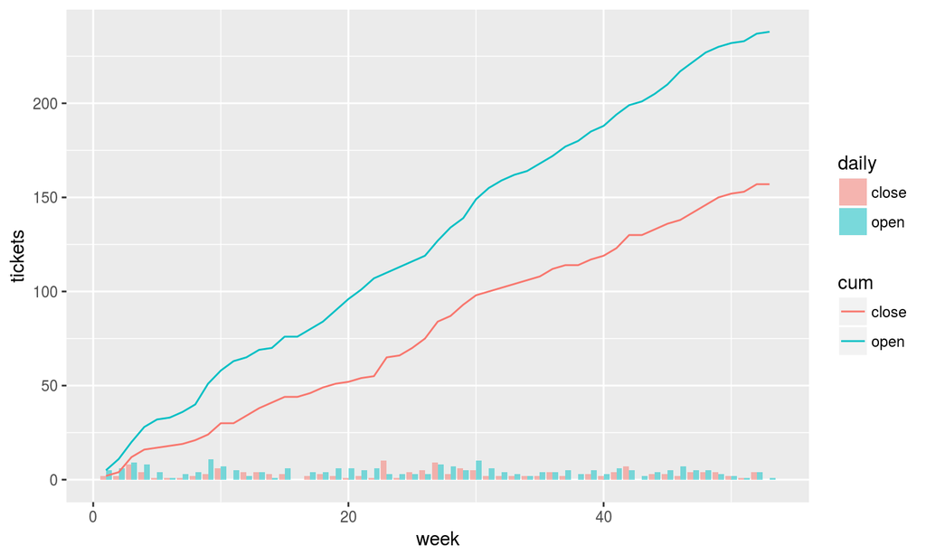

## ヒント

ノーヒント

## 演習９

## 複数の因子で層別する

`ToothGrowth`データセットを用いて`dose`と`supp`で層別ヒストグラムを描いてください。また、密度推定を重ねてみなさい。

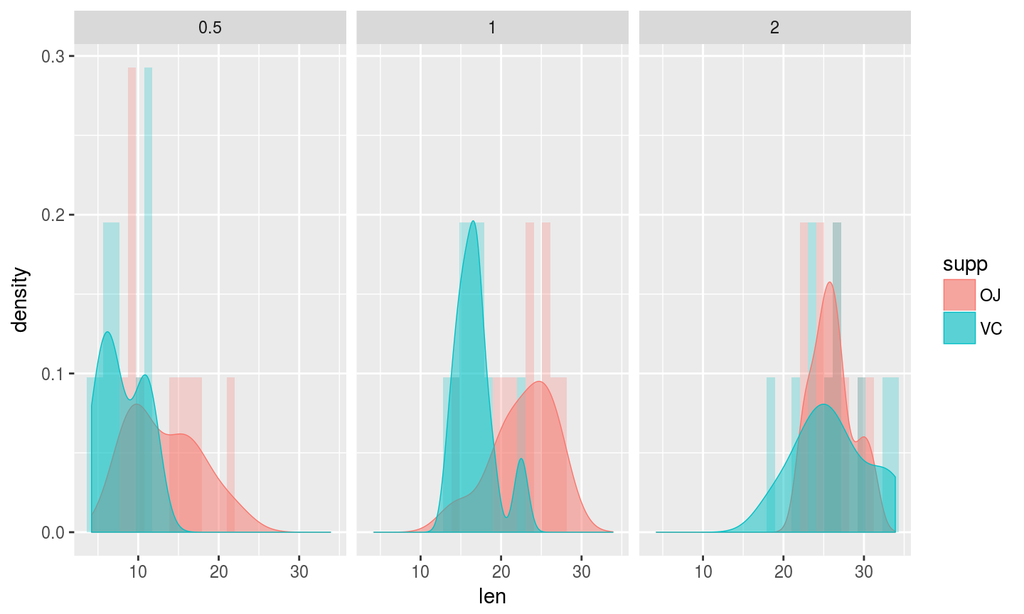

## License

CC BY-NC-SA 4.0, Sampo Suzuki